# DATA 606 Data Project Proposal

Leticia Salazar

$~$

### Data Preparation

```r
# load packages / libraries
library("tidyverse")
library("tidyr")
library("dplyr")
```

$~$

```r
# load data
drinks <- read.csv("https://raw.githubusercontent.com/letisalba/Data-606/main/Project/drinks.csv", header = TRUE, na.strings = c(""," ", "NA"));
```

$~$

```r
glimpse(drinks)
```

```
## Rows: 193
## Columns: 5
## $ country                      <chr> "Afghanistan", "Albania", "Algeria", "And…
## $ beer_servings                <int> 0, 89, 25, 245, 217, 102, 193, 21, 261, 2…
## $ spirit_servings              <int> 0, 132, 0, 138, 57, 128, 25, 179, 72, 75,…
## $ wine_servings                <int> 0, 54, 14, 312, 45, 45, 221, 11, 212, 191…
## $ total_litres_of_pure_alcohol <dbl> 0.0, 4.9, 0.7, 12.4, 5.9, 4.9, 8.3, 3.8, …
```

$~$

```r
# Get column names
names(drinks)
```

```
## [1] "country"                      "beer_servings"
## [3] "spirit_servings"              "wine_servings"
## [5] "total_litres_of_pure_alcohol"
```

$~$

```r
# Rename columns
colnames(drinks) <- c("Country", "Beer_Servings", "Spirit_Servings", "Wine_Servings", "Total_Litres_Pure_Alcohol")
```

$~$

### Research question

**You should phrase your research question in a way that matches up with the scope of inference your data set allows for.**

*What country has the highest alcohol consumption?*

$~$

### Cases

**What are the cases, and how many are there?**

*Each case represents a country around the world along with their beer, spirits and/or wine number of servings, as well as the total liters of pure alcohol. There are 193 total observations in this data set.*

$~$

### Data collection

**Describe the method of data collection.**

*The data was collected from [FiveThirtyEight’s](https://fivethirtyeight.com/features/dear-mona-followup-where-do-people-drink-the-most-beer-wine-and-spirits/) article called “Dear Mona Followup: Where Do People Drink The Most Beer, Wine And Spirits?” This data was collected by World Health Organisation, Global Information System on Alcohol and Health (GISAH), 2010.*

$~$

### Type of study

**What type of study is this (observational/experiment)?**

*This is an observational study.*

$~$

### Data Source

**If you collected the data, state self-collected. If not, provide a citation/link.**

*World Health Organization. (n.d.). Global information system on alcohol and health. World Health Organization. Retrieved October 19, 2021, from https://www.who.int/data/gho/data/themes/global-information-system-on-alcohol-and-health.*

$~$

### Dependent Variable

**What is the response variable? Is it quantitative or qualitative?**

*The dependent variable is alcohol consumption and it it quantitative.*

$~$

### Independent Variable

**What is the independent variable? Is it quantitative or qualitative?**

*The independent variable is country and it is a qualitative.*

$~$

### Relevant summary statistics

**Provide summary statistics for each the variables. Also include appropriate visualizations related to your research question (e.g. scatter plot, boxplots, etc). This step requires the use of R, hence a code chunk is provided below. Insert more code chunks as needed.**

```r
summary(drinks$Country)
```

```
##    Length     Class      Mode
##       193 character character
```

$~$

```r
summary(drinks$Beer_Servings)
```

```
##    Min. 1st Qu.  Median    Mean 3rd Qu.    Max.
##     0.0    20.0    76.0   106.2   188.0   376.0
```

$~$

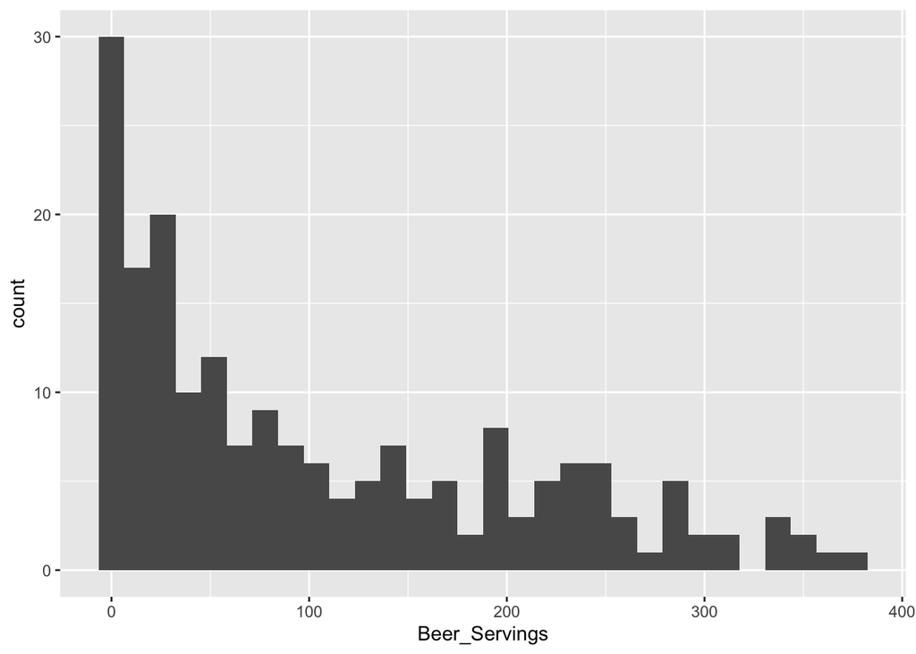

```r
drinks %>%
ggplot(aes(x = Beer_Servings)) +
  geom_histogram()
```

$~$

```r
summary(drinks$Spirit_Servings)
```

```
##    Min. 1st Qu.  Median    Mean 3rd Qu.    Max.
##    0.00    4.00   56.00   80.99  128.00  438.00
```

$~$

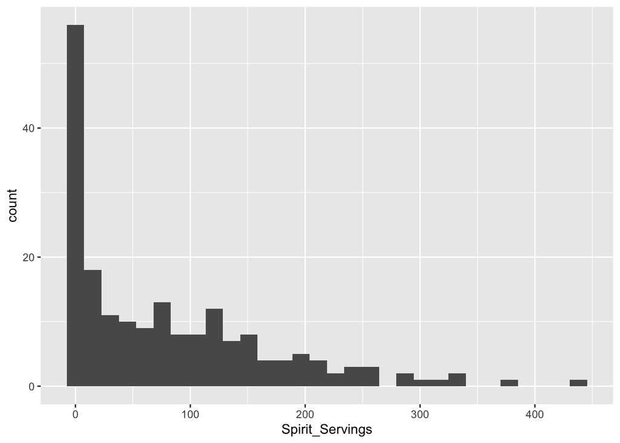

```r
drinks %>%
ggplot(aes(x = Spirit_Servings)) +
  geom_histogram()
```

$~$

```r
summary(drinks$Wine_Servings)
```

```
##    Min. 1st Qu.  Median    Mean 3rd Qu.    Max.
##    0.00    1.00    8.00   49.45   59.00  370.00
```

$~$

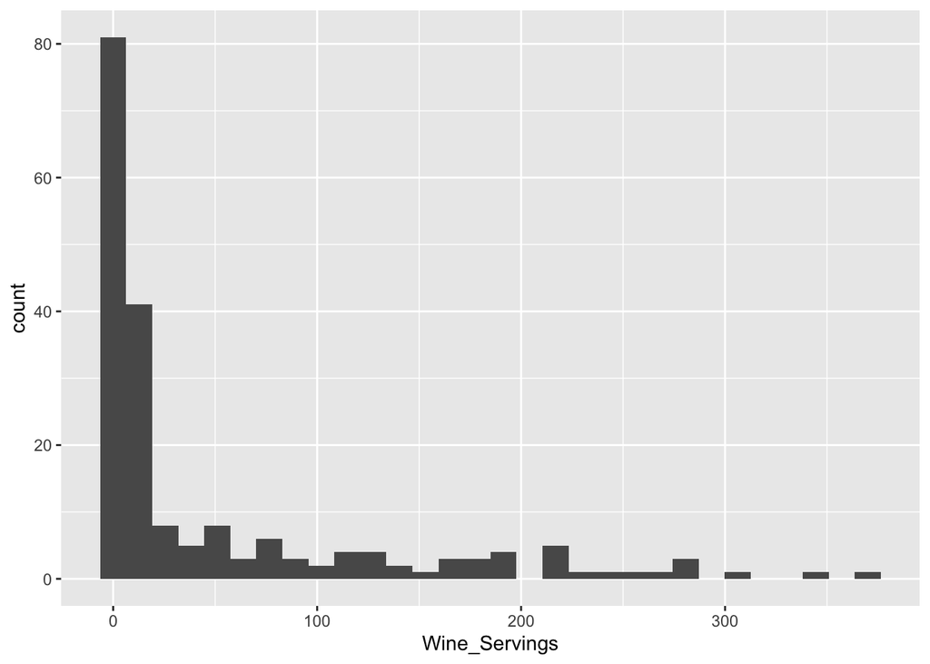

```r
drinks %>%
ggplot(aes(x = Wine_Servings)) +
  geom_histogram()
```

$~$

```r
summary(drinks$Total_Litres_Pure_Alcohol)
```

```
##    Min. 1st Qu.  Median    Mean 3rd Qu.    Max.
##   0.000   1.300   4.200   4.717   7.200  14.400
```

$~$

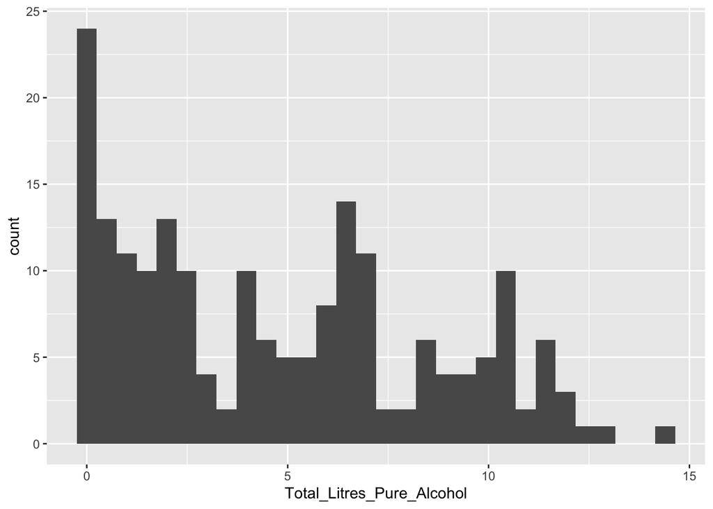

```r
drinks %>%
ggplot(aes(x = Total_Litres_Pure_Alcohol)) +
  geom_histogram()
```